# Confidence Intervals

**Зад 1.** Острата левкемия е една от най-смъртноносните форми на рак. Предишни изследвания показват, че впемето на преживяване след първоначалното откриване на левкемия е нормално разпределена случайна величина с математическо очакване 13 месеца и стандартно отклонение 3 месеца. Въвежда се ново лечение, което се очаква да удължи средното време на живот без да повлияе на дисперсията. Наблюдавани са 16 пациента: 10.0 13.6 13.2 11.6 12.5 14.2 14.9 14.5 13.4 8.6 11.5 16.0 14.2 16.8 17.9 17.0 Да се намери оценка за очакването. Да се построи 95% доверителен интервал за средното време на живот на болните.

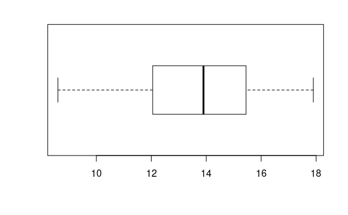

```r
x = c(10.0, 13.6, 13.2, 11.6, 12.5, 14.2, 14.9, 14.5, 13.4, 8.6, 11.5, 16.0, 14.2, 16.8, 17.9, 17.0)
boxplot(x, horizontal = T)
```

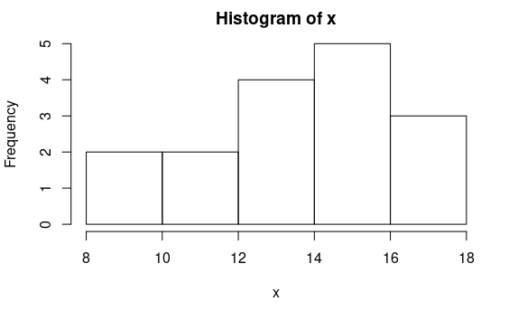

```r
hist(x)
```

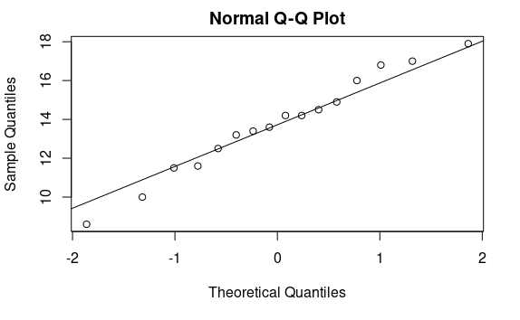

```r
qqnorm(x)
qqline(x)
```

```r
shapiro.test(x)
```

```
    Shapiro-Wilk normality test

data:  x
W = 0.97917, p-value = 0.9567
```

> Приемаме, че данните са нормално разпределени

```r
t.test(x)
```

```
    One Sample t-test

data:  x
t = 21.65, df = 15, p-value = 9.976e-13
alternative hypothesis: true mean is not equal to 0
95 percent confidence interval:
 12.39066 15.09684
sample estimates:
mean of x
 13.74375
```

> 95 percent confidence interval: 12.39066 - 15.09684

**Зад. 2** Постройте 95% и 90% доверителен интервал за средното време на живот на болните.

```r
t.test(x, conf.level = 0.95)
```

[output not shown]

```r
t.test(x, conf.level = 0.90)
```

[output not shown]

**Зад. 3** Генерирайте 20 нблюдения над случайна величина, която е нормално разпределена с очакване 5, и дисперсия 4. Постройте 90% процентен доверителен интервал за математическото очакване. Мовторете опита 100 пъти. Проверете в колко от случаите математическото очакване принадлежи на доверителния интервал.

```r
r = rnorm(20, 5, 2)
t.test(r, conf.level = 0.90)
```

```
    One Sample t-test

data:  r
t = 8.227, df = 19, p-value = 1.103e-07
alternative hypothesis: true mean is not equal to 0
90 percent confidence interval:
 3.220878 4.935072
sample estimates:
mean of x
 4.077975
```

```r
count = 0
for(i in 1:100){
  r = rnorm(20, 5, 2)
  t = t.test(r, conf.level = 0.90)
  if (5 < t$conf.int[2] & 5 > t$conf.int[1]) {
    count = count +  1
  }
}
count
```

[output not shown]

**Зад. 5** При провеждане на анкета 87 от 150 анкетирани са отговорили, че са изплозвали даден продукт. Постройте 92% доверителен интервал за броя на хората, използвали продукта. > x1, …, x150 > xi <- Bi(1, p)

```r
p = prop.test(87,150, conf.level = 0.92)
p
```

```
    1-sample proportions test with continuity correction

data:  87 out of 150, null probability 0.5
X-squared = 3.5267, df = 1, p-value = 0.06039
alternative hypothesis: true p is not equal to 0.5
92 percent confidence interval:
 0.5051991 0.6514474
sample estimates:
   p
0.58
```

**Зад. 6** Постройте 96% доверителен интервал за средната стойност по данните:  
**a)** rat  
**b)** exec.pay  
**c)** malpract

> t.test if X <- N  
> wilcox.test otherwise

```r
library(UsingR)
shapiro.test(rat)
```

```
    Shapiro-Wilk normality test

data:  rat
W = 0.96134, p-value = 0.571
```

```r
t.test(rat, conf.level = 0.96)
```

```
    One Sample t-test

data:  rat
t = 14.176, df = 19, p-value = 1.48e-11
alternative hypothesis: true mean is not equal to 0
96 percent confidence interval:
  95.80624 131.09376
sample estimates:
mean of x
   113.45
```

```r
shapiro.test(exec.pay)
```

```
    Shapiro-Wilk normality test

data:  exec.pay
W = 0.19352, p-value < 2.2e-16
```

```r
wilcox.test(exec.pay, conf.int = T, conf.level = 0.96)
```

```
    Wilcoxon signed rank test with continuity correction

data:  exec.pay
V = 19306, p-value < 2.2e-16
alternative hypothesis: true location is not equal to 0
96 percent confidence interval:
 25.99996 33.00003
sample estimates:
(pseudo)median
      29.00002
```

```r
shapiro.test(malpract)
```

```
    Shapiro-Wilk normality test

data:  malpract
W = 0.80547, p-value = 0.002414
```

```r
wilcox.test(malpract, conf.int = T, conf.level = 0.96)
```

```
    Wilcoxon signed rank test

data:  malpract
V = 153, p-value = 1.526e-05
alternative hypothesis: true location is not equal to 0
96 percent confidence interval:
  315 1525
sample estimates:
(pseudo)median
           800
```